# Modelling the impact of increasing sources using Bayesian, non-linear (power function) regressions

Author

Manikya Alister

```r
library(tidyverse)
library(posterior)
library(here)
library(ggdist)

# define experiments
experiments = c(3)

# load model fits
fits = list()
for (exp in experiments){
load(here(paste0("output/fe-brms-exp",exp,"-power-fit-full.Rdata")))
fits[[exp]] <- fit
}
```

There are a few reasons why I think modelling this kind of problem using non-linear regression, especially one that follows a power (or any asymptotic growth) function is useful. First, it has unique predictive value, allowing us to estimate how increasing the number of sources will increase confidence, even if we do not have direct empirical measurements for a given source number. This can therefore allow us to do things like predict when adding new sources will stop increasing confidence as a function of different types of consensus manipulations (e.g., independence), with minimal data.

Second, if there are differences in how independence (or any other manipulation, like expertise) affects the consensus X source number relationship, non-linear modelling like this allows us to make inferences about what is driving these differences. Using a power function, like I do here, we can infer whether source independence affects the rate at which confidence increases with multiple sources, whether it affects the highest possible confidence (asymptote) that increasing the number of sources will produce, or both. Therefore, I think doing this kind of analysis can provide added benefit beyond something like a mixed source number X independence ANOVA. That being said, you might not think the extra insights that can be gained by this approach are that important for the current study, which I would completely understand! I have been wanting to try this kind of analysis for a while, so it won’t have been a waste of time for me if we don’t end up using it.

# Evaluating model fit

Here, we can see whether the functional (power) form, describes the relationship between confidence and number of sources for both independence types.

```r
d_predictions <- NULL
d_empirical_summ <- NULL

for (exp in experiments) {

  # get predictions from estimated parameters for each experiment and load actual experiment data for each experiment

  fit <- fits[[exp]]


  # load and combine empirical data
  load(here("data/experiment-3/clean/d-modelling.Rdata"))

  # summarise empirical data for plotting
  d_summ_exp <- d_modelling %>%
    mutate(additional_sources = n_sources - 1) %>%
    group_by(consensus, additional_sources) %>%
    summarise(mean = mean(confidence),
              sd = sd(confidence),
              n = n()) %>%
    mutate(se = sd / sqrt(n),
           experiment = exp)

  d_empirical_summ <- bind_rows(d_empirical_summ, d_summ_exp)

  # Make a prediction grid that spans all values of n_sources for both consensus types
  mean_prior_belief <- mean(d_modelling$prior_belief, na.rm = TRUE)

  new_data <- expand.grid(
  n_sources = seq(1, 10, length.out = 50),
  consensus = c("dependent", "independent", "dependent_source"),
  prior_belief = mean_prior_belief
) %>%
  as_tibble()

new_data$consensus <- relevel(new_data$consensus, ref = "independent")


# Predict using fixed effects only (no partial pooling)
  d_predictions_exp  <- fitted(fit, newdata = new_data, re_formula = NA) %>%
  as_tibble() %>%
  bind_cols(new_data) %>%
  mutate(
    additional_sources = n_sources - 1,
    experiment = exp
  )

  d_predictions <- bind_rows(d_predictions, d_predictions_exp)


}
```

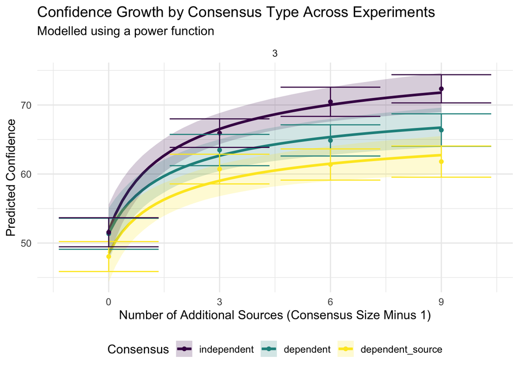

```r
plot <- d_predictions %>%
  ggplot(aes(x = additional_sources, color = consensus, fill = consensus)) +
  geom_line(size = 1.2, aes(y = Estimate)) +
  geom_ribbon(aes(ymin = Q2.5, ymax = Q97.5, y = Estimate), alpha = 0.2, color = NA) +
  geom_point(data = d_empirical_summ, aes(y = mean))+
  geom_errorbar(data = d_empirical_summ, aes(ymin = mean - se, ymax = mean + se))+
  facet_grid(~experiment)+
  labs(
    x = "Number of Additional Sources (Consensus Size Minus 1)",
    y = "Predicted Confidence",
    title = paste0("Confidence Growth by Consensus Type Across Experiments"),
    subtitle = "Modelled using a power function",
    color = "Consensus",
    fill = "Consensus"
  ) +
  scale_fill_viridis_d(option = "D")+
  scale_colour_viridis_d(option = "D")+
  scale_x_continuous(breaks = seq(0,9,3))+
  theme_minimal(base_size = 12)+
  theme(legend.position = "bottom")

plot
```

```r
ggsave(plot = plot, filename = here(paste0("plots/fe-brms-power-fit.jpg")), width = 7, height = 4)
```

Seems like it does pretty well! I’ve also had a look at some other similar functions, like log or exponential functions, and found that log & power fit similarly better than exponential, but I chose power because I find the parameters more interperetable.

Now that we know the model fits well, and we can see that an independent consensus clearly results in greater increases in confidence as a function of the number of sources, we can try and figure out what is driving these differences. Specifically, whether it is rate of increase, asymptote, or both.

# Compare parameters across conditions

The table below shows the absolute means an 95% credible differences between parameters, as well as the *relative* means and 95% credible differences between parameters across independence conditions. The relative differences were calculated because the parameters are on different scales (small differences in rate result in big differences in shape of the curve), so this allows us to see by what % is the parameter in the independent condition than the equivalent in the dependent condition.

```r
param_contrasts_summary <- NULL
param_contrasts_long <- NULL
intercept_level <- c("Dependent" = "consensusdependent")
comparison_levels <- c("Independent" = "consensusindependent", "Dependent Source" = "consensusdependent_source")


for (exp in experiments) {
  fit <- fits[[exp]]

  print("Model fit: ")
  #print(summary(fit)$fixed %>% select(-Bulk_ESS,-Tail_ESS))

  # Extract draws
  draws <- as_draws_df(fit)

  # 2. Helper to extract and transform parameters
  get_param_contrasts <- function(draws,
                                  param_name,
                                  condition_effect_name) {
    # asymptote is start + increase
    if (param_name == "asymptote") {
      start_intercept <- draws[["b_start_Intercept"]]
      increase_intercept <- draws[["b_increase_Intercept"]]

      intercept <- exp(start_intercept) + exp(increase_intercept)
      condition_effect <- exp(start_intercept + draws[[paste0("b_start_", condition_effect_name)]]) + exp(increase_intercept + draws[[paste0("b_increase_", condition_effect_name)]]) #+ intercept

    } else{
      intercept_raw <- draws[[paste0("b_", param_name, "_Intercept")]]
      intercept <- exp(intercept_raw)
      condition_effect <- exp(intercept_raw + draws[[paste0("b_", param_name, "_", condition_effect_name)]])
    }

    tibble(
      parameter = param_name,
      condition_effect_name = condition_effect_name,
      condition_effect = condition_effect,
      intercept = intercept,
      abs_diff = intercept - condition_effect,
      rel_diff = (intercept - condition_effect) / condition_effect
    )
  }

  # Individual parameter contrasts
  log_params <- c("rate", "asymptote", "start")

  for (i in 1:length(comparison_levels)) {
    comparison_level <- comparison_levels[i]
    param_contrasts <- bind_rows(lapply(log_params, function(p)
      get_param_contrasts(draws, p, comparison_level)))

    # 5. Summarise posterior contrasts
    param_contrast_summ_exp <- param_contrasts %>%
      group_by(parameter) %>%
      summarise(
        mean_cond_effect = mean(condition_effect),
        mean_intercept = mean(intercept),
        mean_abs_diff = mean(abs_diff),
        ci_abs_lower = quantile(abs_diff, 0.025),
        ci_abs_upper = quantile(abs_diff, 0.975),
        prob_intercept_gt_contrast = mean(abs_diff > 0),
        prob_intercept_lt_contrast = mean(abs_diff < 0),
        prob_intercept_diff_contrast = prob_intercept_gt_contrast - prob_intercept_lt_contrast,


        mean_rel_diff = mean(rel_diff),
        ci_rel_lower = quantile(rel_diff, 0.025),
        ci_rel_upper = quantile(rel_diff, 0.975)
      ) %>%
      arrange(match(parameter, c(
        "rate", "increase", "start", "asymptote"
      )))

    print(paste0(names(intercept_level), " vs. ", names(comparison_level)))
    #param_contrast_summ_exp <- param_contrasts_summary[[1]]

    print(knitr::kable(
      param_contrast_summ_exp %>% select(
        parameter,
        mean_cond_effect,
        mean_intercept,
        mean_abs_diff,
        ci_abs_lower,
        ci_abs_upper,
        mean_rel_diff,
        ci_rel_lower,
        ci_rel_upper
      )
    ))


    print(
      paste0(
        "Probability that parameter in ",
        names(intercept_level),
        " condition > ",
        names(comparison_level),
        " condition:"
      )
    )
    print(param_contrast_summ_exp %>% select(parameter, prob_intercept_gt_contrast))
    print(
      paste0(
        "Probability that parameter in ",
        names(intercept_level),
        " condition < ",
        names(comparison_level),
        " condition:"
      )
    )
    print(param_contrast_summ_exp %>% select(parameter, prob_intercept_lt_contrast))

    param_contrasts_summary[[exp]] <- param_contrast_summ_exp %>%
      filter(parameter != "increase")

    param_contrasts_long_exp <- param_contrasts %>%
      pivot_longer(
        cols = c(condition_effect, intercept),
        names_to = "consensus",
        values_to = "value"
      ) %>%
      mutate(
        experiment = exp,
        comparison = case_when(
          condition_effect_name == "consensusindependent" ~ "Dependent vs. Independent",
          condition_effect_name == "consensusdependent_source" ~ "Dependent vs. Dependent Source"
        )
      )

    param_contrasts_long <- bind_rows(param_contrasts_long, param_contrasts_long_exp)
  }
}
```

```
[1] "Model fit: "
[1] "Dependent vs. Independent"


|parameter | mean_cond_effect| mean_intercept| mean_abs_diff| ci_abs_lower| ci_abs_upper| mean_rel_diff| ci_rel_lower| ci_rel_upper|
|:---------|----------------:|--------------:|-------------:|------------:|------------:|-------------:|------------:|------------:|
|rate      |         0.530408|       0.516397|    -0.0140109|   -0.2508558|    0.1685173|     0.0068206|   -0.3156020|    0.4481714|
|start     |        51.775031|      51.399913|    -0.3751171|   -5.5728060|    4.8939495|    -0.0057732|   -0.1036821|    0.0991666|
|asymptote |        81.349530|      73.907939|    -7.4415915|  -17.2092123|    0.3851919|    -0.0891777|   -0.1893981|    0.0049582|
[1] "Probability that parameter in Dependent condition > Independent condition:"
# A tibble: 3 × 2
  parameter prob_intercept_gt_contrast
  <chr>                          <dbl>
1 rate                          0.475
2 start                         0.444
3 asymptote                     0.0308
[1] "Probability that parameter in Dependent condition < Independent condition:"
# A tibble: 3 × 2
  parameter prob_intercept_lt_contrast
  <chr>                          <dbl>
1 rate                           0.525
2 start                          0.556
3 asymptote                      0.969
[1] "Dependent vs. Dependent Source"


|parameter | mean_cond_effect| mean_intercept| mean_abs_diff| ci_abs_lower| ci_abs_upper| mean_rel_diff| ci_rel_lower| ci_rel_upper|
|:---------|----------------:|--------------:|-------------:|------------:|------------:|-------------:|------------:|------------:|
|rate      |        0.5349449|       0.516397|    -0.0185478|   -0.2457211|    0.1643994|     0.0005339|   -0.3177323|    0.4510237|
|start     |       48.5388536|      51.399913|     2.8610600|   -2.5584969|    8.1861885|     0.0608846|   -0.0492489|    0.1817540|
|asymptote |       69.4535863|      73.907939|     4.4543524|   -3.7848459|   11.5117462|     0.0664516|   -0.0509813|    0.1761042|
[1] "Probability that parameter in Dependent condition > Dependent Source condition:"
# A tibble: 3 × 2
  parameter prob_intercept_gt_contrast
  <chr>                          <dbl>
1 rate                           0.460
2 start                          0.84
3 asymptote                      0.879
[1] "Probability that parameter in Dependent condition < Dependent Source condition:"
# A tibble: 3 × 2
  parameter prob_intercept_lt_contrast
  <chr>                          <dbl>
1 rate                           0.540
2 start                          0.16
3 asymptote                      0.121
```

It looks like that for neither the independent vs. dependent comparison, nor the dependent vs dependent_source comparison, are any parameters fully reliably different at a 95% credible interval (there’s some overlap). But it does seem still much closer for the independent comparison than the dependent_source comparison. Also, when you look at how probable it is that asymptote in the Dependent condition < Independent condition, there is a 97% probability that there is a difference. FOr dependent vs. dependent_source, there’s an 87% probability that dependnent > dependent_source. So even though they’re small differences, and the 95% credible interval are not showing completely reliable differences, there is still some evidence to suggest differences, especially in the independent comparison– it just depends on how conservative you want to be. The plot show this more clearly.

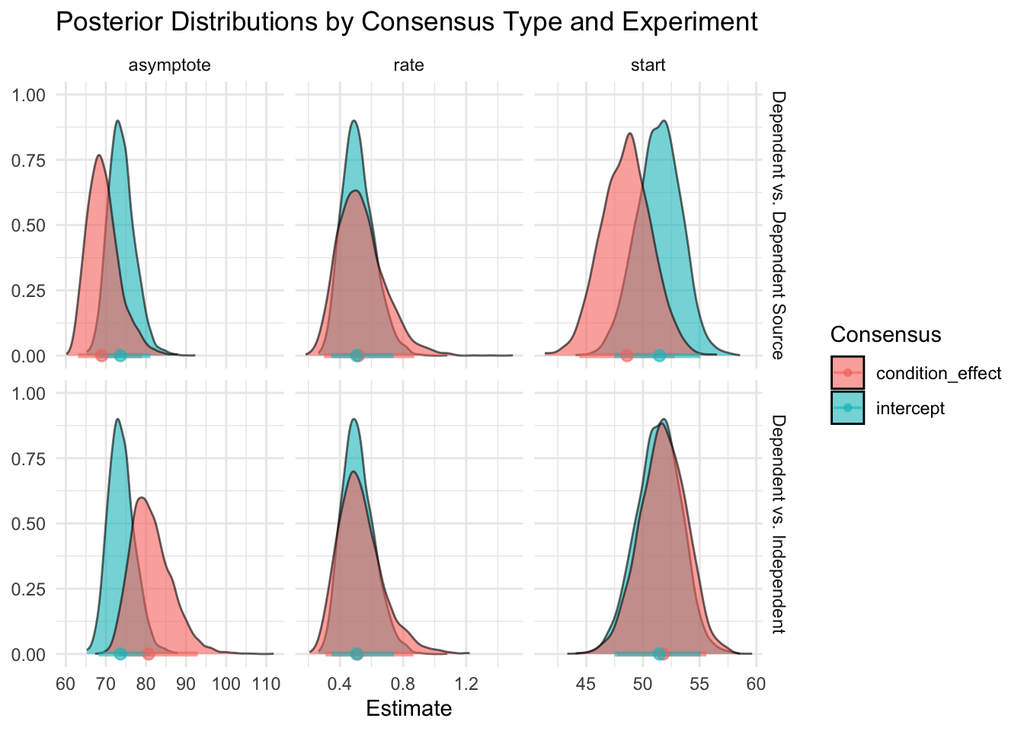

```r
# Plot

param_contrasts_long %>%
  filter(parameter != "increase") %>% # remove increase parameter because it is basically the same as asymptote
ggplot(aes(x = value, colour = consensus, fill = consensus)) +
  stat_halfeye(alpha = 0.6, slab_linewidth = 0.5, slab_color = "black",  normalize = "xy", .width = .95) +
  #facet_wrap(condition_effect_name~parameter, scales = "free_x")+
  facet_grid(comparison ~ parameter, scales = "free") +
  theme_minimal() +
  labs(
    title = "Posterior Distributions by Consensus Type and Experiment",
   # subtitle = paste0("Experiment ", experiment),
    x = "Estimate",
    y = NULL,
    fill = "Consensus",
    color = "Consensus"
  )
```

Above, the plot shows that there are much more reliable differences between the independent and dependent asymptote compared to the dependent vs. dependent source. Something that could be messing the asymptote reliability up a bit though is the difference in the starting points. For some reason, the samples in the dependent source group had a lower starting point in the baseline condition, which is a bit strange, but could be suppressing the influence of asymptote.

One thing that I’ve done is just look at the probability that a a paramter in one condition is greater than that of the other condition by looking at the proportion of samples where the difference between conditions was greater than 0. Looking at this, it seems like much stronger evidence for asymptote differences across conditions, with 97% probability that asymptote in the independent condition is greater than that in dependent, and 88% probability that asymptote in the dependent condition is greater than that in the dependent source condition. When we look at the same for rate, these probabilities are close to 50%, suggesting that any differences are most likely being driven by asymptote.

# Model comparison

Another way to try and figure out which parameters are varying across conditions is to perform a model comparison, where we compare models that either allow certain parameters to vary across consensus conditions or not. In other words, it lets us figure out whether assuming that a parameter, such as rate, is different in the independent vs. dependent vs. dependent source condition actually makes the fit relative to complexity better. I ran 8 models, with all possible combination of parameters varying as a function of consensus, where “full” is all parameters varying, and “none” is assuming that parameters are the same across consensus conditions.

```r
load(file = here("output/looic-model-comparison.Rdata"))
print("Results of model comparison ordered from best (left) to worst (right) according to LOOIC: ")
```

```
[1] "Results of model comparison ordered from best (left) to worst (right) according to LOOIC: "
```

```r
model_looic
```

```
      increase           rate  rate_increase     start_rate          start
      12017.02       12017.62       12017.66       12018.63       12019.08
start_increase           full           none
      12019.51       12019.59       12036.30
```

The results suggest that only allowing the increase (asymptote) parameter to vary across time results in the best model performance relative to complexity. It’s worth noting though, that the difference between all of the models that assume at least one parameter varies across consensus conditions is quite small (i.e., all models except “none” are separated by only a few points). This fairly large difference between full vs. none suggests so me that there is pretty strong differences across consensus conditions, but this could be mainly driven by the independent condition being quite different from the dependent and dependent source conditions.

Overall, between the model comparison and the parameter estimates I’d interpret this as there being some evidence there is a) differences between conditions and that b) these difference are driven by asymptote. asymptote between con between independent and the rest, and some evidence to suggest differences beteween dependent and dependent_source, but they’re smaller and less reliable.